# Class 21: Model Validation

Hughes/Fisher

## Model validation

The main concept of *model validation* is to evaluate the model you have built. In most applications, we measure models based on their predictive accuracy … in other words, how well the model predicts the response variable of interest.

Measures such as $R^2$ or $R_{adj}^2$ provide a measure of model prediction accuracy, however they are inheritely biased because the **same** data is used to both build the model **and** assess the predictive accuracy. Surely a fitted model will optimize its predictive accuracy if the same data is used to fit the model and assess its accuracy!

To handle this sort of situation, the simple solution is to get more data!

- Fit the model based on one set of data.
- Assess its predictive accuracy using a different (new) set of observations.

In practice, collecting more data is not always feasible. In such cases, we perform **model validation** studies.

### Data example and preparation

Before proceeding with the statistical details, let’s first look at today’s example: **Happiness**.

In the file `happiness2016.csv` is the happiness index record for most countries in the world in 2016. Our goal for today is to try and predict a country’s happiness based on other information about the country.

```r
happiness <- read.csv("happiness2016.csv") %>%
  select(Country, Region, Happiness.Score)
```

Two variables we will consider are the gun ownership and homicide rates for that country. We used this data few weeks ago:

```r
guns <- read.csv("firearmsMurderOwnership.csv") %>%
  rename(Country=Country.Territory,
         Homicides = Homicide.by.firearm.rate.per.100.000.pop,
         Gunrate = Average.firearms.per.100.people) %>%
  select(Country, Homicides, Gunrate)
```

We also considered the Inequality-adjusted Human Development Index values, from a different data set:

```r
iahd <- read.csv("iahd-index.csv", skip=6, header=FALSE, na.strings="..") %>%
  select(V2, V5 ) %>%
  rename(Country=V2, IHDI=V5)
```

Lastly, we will consider the life expectancy, population and Gross Domestic Product (per capita) for each country as collected by *gapminder*:

```r
gap2007 <- read.csv("gapminder2007.csv")
```

We merge all this data together using an `inner_join` statement, so only countries in all four data files are retained.

```r
full.data <- happiness %>%
  inner_join(., guns, by="Country") %>%
  inner_join(., iahd, by="Country") %>%
  inner_join(., gap2007, by="Country") %>%
  drop_na()
head(full.data)  # check the top of the data set
```

```
##       Country         Region Happiness.Score Homicides Gunrate      IHDI
## 1     Denmark Western Europe           7.526      0.27    12.0 0.8583194
## 2 Switzerland Western Europe           7.509      0.77    45.7 0.8585701
## 3     Iceland Western Europe           7.501      0.00    30.3 0.8676488
## 4      Norway Western Europe           7.498      0.05    31.3 0.8979069
## 5     Finland Western Europe           7.413      0.45    45.3 0.8428393
## 6      Canada  North America           7.404      0.51    30.8 0.8386826
##   lifeExp      pop gdpPercap
## 1  78.332  5468120  35278.42
## 2  81.701  7554661  37506.42
## 3  81.757   301931  36180.79
## 4  80.196  4627926  49357.19
## 5  79.313  5238460  33207.08
## 6  80.653 33390141  36319.24
```

```r
tail(full.data)  # check the bottom of the data set
```

```
##      Country                          Region Happiness.Score Homicides Gunrate
## 83     Egypt Middle East and Northern Africa           4.362      0.57     3.5
## 87  Bulgaria      Central and Eastern Europe           4.217      0.67     6.2
## 89  Zimbabwe              Sub-Saharan Africa           4.193      4.78     4.4
## 97  Cambodia               Southeastern Asia           3.907      1.44     4.3
## 102   Uganda              Sub-Saharan Africa           3.739      0.87     1.4
## 104  Liberia              Sub-Saharan Africa           3.622      0.43     1.6
##          IHDI lifeExp      pop  gdpPercap
## 83  0.4910783  71.338 80264543  5581.1810
## 87  0.7088854  73.005  7322858 10680.7928
## 89  0.3685057  43.487 12311143   469.7093
## 97  0.4363314  59.723 14131858  1713.7787
## 102 0.3406198  51.542 29170398  1056.3801
## 104 0.2842962  45.678  3193942   414.5073
```

```r
dim(full.data)   # find the dimensions (no of rows and columns) of the data set
```

```
## [1] 67  9
```

You’ll note in the above that we drop all observations that contain any missing values (`NA`). We do this for ease, but many of the methods we describe below would work if `NA` values were included.

Let’s visualize the numeric variables, specifying the happiness rating as last (it’s in column 3):

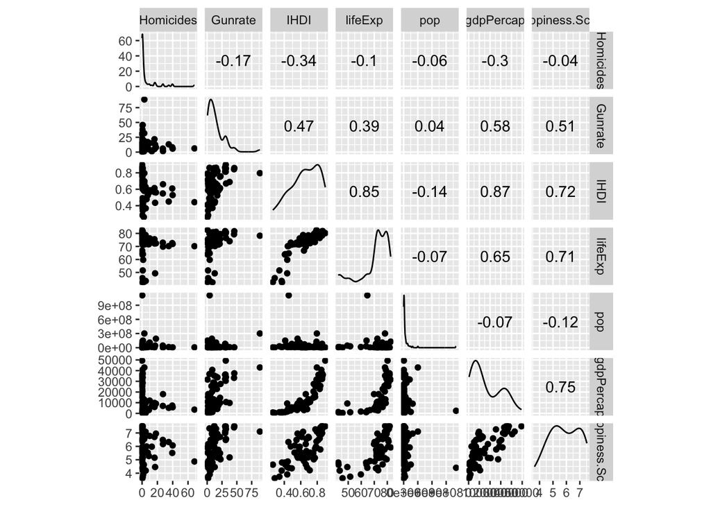

```r
ggscatmat(full.data, columns=c(4,5,6,7,8,9,3))
```

Several variables are clearly heavily skewed (population, homicide rates, GDP). We can *fix* some of that skewness with a log transformation:

```r
logged.data <- full.data %>%
  mutate(Homicides = log(Homicides+1),
         Gunrate = log(Gunrate),
         pop = log(pop),
         gdpPercap = log(gdpPercap))
```

Note the `Homicides = log(Homicides+1)`: **why the `+1`??**

Now graphically look at the numeric variables with transformations invoked:

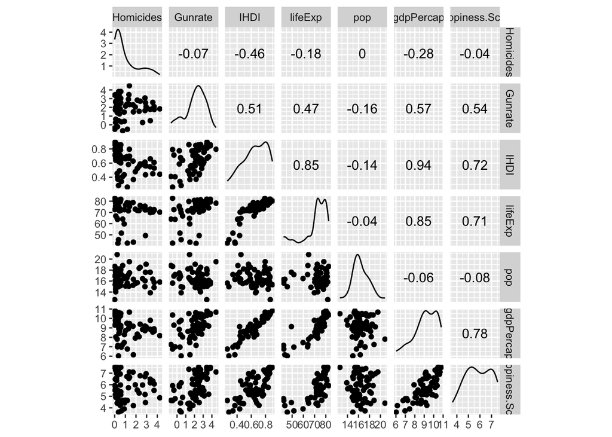

```r
ggscatmat(logged.data, columns=c(4,5,6,7,8,9,3))
```

Let’s begin by fitting two models: a full model *and* a model based on backward selection.

```r
full.model <- lm(Happiness.Score ~ Homicides + Gunrate + IHDI + lifeExp + pop + gdpPercap, data=logged.data)
back.select <- step(full.model, direction="backward")
```

```
## Start:  AIC=-45.47
## Happiness.Score ~ Homicides + Gunrate + IHDI + lifeExp + pop +
##     gdpPercap
##
##             Df Sum of Sq    RSS     AIC
## - pop        1   0.00118 27.583 -47.462
## - lifeExp    1   0.12996 27.712 -47.150
## - IHDI       1   0.34012 27.922 -46.644
## <none>                   27.582 -45.465
## - Gunrate    1   0.85632 28.438 -45.417
## - gdpPercap  1   1.18145 28.763 -44.655
## - Homicides  1   2.01400 29.596 -42.743
##
## Step:  AIC=-47.46
## Happiness.Score ~ Homicides + Gunrate + IHDI + lifeExp + gdpPercap
##
##             Df Sum of Sq    RSS     AIC
## - lifeExp    1   0.13871 27.722 -49.126
## - IHDI       1   0.37046 27.953 -48.568
## <none>                   27.583 -47.462
## - Gunrate    1   0.86864 28.451 -47.385
## - gdpPercap  1   1.30553 28.888 -46.364
## - Homicides  1   2.11103 29.694 -44.521
##
## Step:  AIC=-49.13
## Happiness.Score ~ Homicides + Gunrate + IHDI + gdpPercap
##
##             Df Sum of Sq    RSS     AIC
## - IHDI       1   0.74587 28.468 -49.347
## <none>                   27.722 -49.126
## - Gunrate    1   0.84122 28.563 -49.123
## - gdpPercap  1   1.39727 29.119 -47.831
## - Homicides  1   2.91525 30.637 -44.427
##
## Step:  AIC=-49.35
## Happiness.Score ~ Homicides + Gunrate + gdpPercap
##
##             Df Sum of Sq    RSS     AIC
## - Gunrate    1    0.7896 29.257 -49.514
## <none>                   28.467 -49.347
## - Homicides  1    2.2005 30.668 -46.359
## - gdpPercap  1   27.8798 56.347  -5.602
##
## Step:  AIC=-49.51
## Happiness.Score ~ Homicides + gdpPercap
##
##             Df Sum of Sq    RSS     AIC
## <none>                   29.257 -49.514
## - Homicides  1     2.526 31.783 -45.966
## - gdpPercap  1    50.208 79.465  15.432
```

```r
summary(full.model)
```

```
##
## Call:
## lm(formula = Happiness.Score ~ Homicides + Gunrate + IHDI + lifeExp +
##     pop + gdpPercap, data = logged.data)
##
## Residuals:
##      Min       1Q   Median       3Q      Max
## -1.63360 -0.55878  0.03092  0.51896  1.05376
##
## Coefficients:
##              Estimate Std. Error t value Pr(>|t|)
## (Intercept) -0.262111   1.394110  -0.188   0.8515
## Homicides    0.215697   0.103050   2.093   0.0406 *
## Gunrate      0.118791   0.087037   1.365   0.1774
## IHDI         1.831360   2.129071   0.860   0.3931
## lifeExp      0.009815   0.018459   0.532   0.5969
## pop          0.003185   0.062755   0.051   0.9597
## gdpPercap    0.401056   0.250169   1.603   0.1142
## ---
## Signif. codes:  0 '***' 0.001 '**' 0.01 '*' 0.05 '.' 0.1 ' ' 1
##
## Residual standard error: 0.678 on 60 degrees of freedom
## Multiple R-squared:  0.6535, Adjusted R-squared:  0.6189
## F-statistic: 18.86 on 6 and 60 DF,  p-value: 3.394e-12
```

```r
summary(back.select)
```

```
##
## Call:
## lm(formula = Happiness.Score ~ Homicides + gdpPercap, data = logged.data)
##
## Residuals:
##     Min      1Q  Median      3Q     Max
## -1.6896 -0.5707  0.1046  0.5657  1.1133
##
## Coefficients:
##             Estimate Std. Error t value Pr(>|t|)
## (Intercept) -1.36311    0.70202  -1.942   0.0566 .
## Homicides    0.17535    0.07460   2.351   0.0218 *
## gdpPercap    0.76682    0.07317  10.480 1.61e-15 ***
## ---
## Signif. codes:  0 '***' 0.001 '**' 0.01 '*' 0.05 '.' 0.1 ' ' 1
##
## Residual standard error: 0.6761 on 64 degrees of freedom
## Multiple R-squared:  0.6325, Adjusted R-squared:  0.621
## F-statistic: 55.07 on 2 and 64 DF,  p-value: 1.227e-14
```

The model with all the numeric predictor variables has a $R^2_{adj}$ of 0.6189 while the backward stepwise selected model has an $R^2_{adj}$ of 0.621, a very slight improvement. Overall, the backward selection model appears to be a better fit for predicting a countries happiness.

### Validation sets

Obtaining extra data is often impossible, so one idea is to separate your data into two components: one for model building (typically called the **training** set) and the other a leave-out set for model validation (typically called the **testing** or validation set).

There are countless ways to do this in R, but one simple way is to use functionality in the `caret` package.

```r
library(caret)
```

As a first step, we randomly separate our data into two parts, a training and testing set. A standard method of doing this is an 80-20 rule (80% for training, 20% for testing) but other options are just as valid.

**DISCUSSION:** Why random assignment?

```r
set.seed(110718)
trainIndex <- createDataPartition(logged.data$Happiness.Score, p=0.8, list=FALSE)
head(trainIndex)
```

```
##      Resample1
## [1,]         1
## [2,]         2
## [3,]         3
## [4,]         5
## [5,]         6
## [6,]         7
```

```r
train.data <- logged.data %>%
  filter(row_number() %in% trainIndex)
test.data <- logged.data %>%
  filter(!row_number() %in% trainIndex)
```

We now have two datasets, one called `train.data` for which we will use to build models, the other `test.data` that is used for validation. You’ll note we use `set.seed()` so the same *random* set is always picked for the purpose of this demonstration (this ensures reproducibility). We use the function `createDataPartition` and specify `p=0.8` so the training set is approximately 80% of the original data.

Now we can fit the model based on the training set and use that model to predict the testing set. We can then assess the models predictive accuracy (here we use a square root of the mean squared error, typically denoted **RMSE**).

```r
train.fit <- lm(Happiness.Score ~ Homicides + gdpPercap, data=train.data)
test.pred <- predict(train.fit, newdata=test.data)
error <- sqrt( mean((test.data$Happiness.Score - test.pred)^2) )   # Calculation of RMSE
error
```

```
## [1] 0.6188911
```

We see a RMSE of 0.6188911. This value is similar (but also fundamentally different) to the residual standard error, which is reported to be 0.6761 for the backward step-wise selected model.

### Cross-Validation

The above derivation lays the foundation for all validation studies, but it still suffers from a potential drawback. In particular,

- Only 80% of the observed data is ever used for model building, and it is never validated;
- 20% of the data is not used for building, but *only* for validating.

Ideally, we would like to utilize **all** the data for both model building *and* validation. We can do this by repeating the process above some number, say $k$, times. This is known as **$k$-fold cross-validation**. Essentially, it goes like this:

- Randomly segment your data into $k$ groups, each of size $n/k$. For discussion, call the groups 1, 2, 3, $\ldots$, $k$.
- Set aside group 1, and use the combined data in groups 2, 3, $\ldots$, $k$ to build a model, and then validate the model against group 1 (essentially what we did in the previous example).
- Repeat the process where each time you set aside group $i$, and use groups 1, 2, $\ldots$, $i-1$, $i+1$, $\ldots$, $k$ to build a model, and validate it against $k$.
- Aggregate all $k$ error rates into a single overall error rate.

You should note that this process is *very* repetitive, which the computer can do efficiently!

In the `caret` package, we will use the `trainControl` and `train` functions to perform this operation. In the below example, we perform a 5-fold cross-validation study on our model

```r
train_control <- trainControl(method="cv", number=5)
model <- train(Happiness.Score ~ Homicides + gdpPercap, data=logged.data, trControl=train_control, method="lm")
print(model)
```

```
## Linear Regression
##
## 67 samples
##  2 predictor
##
## No pre-processing
## Resampling: Cross-Validated (5 fold)
## Summary of sample sizes: 53, 53, 53, 55, 54
## Resampling results:
##
##   RMSE       Rsquared   MAE
##   0.6958689  0.6183538  0.5961954
##
## Tuning parameter 'intercept' was held constant at a value of TRUE
```

A few things to note:

- 5-fold essentially separates the data into 5 parts, with 20% of the data in each
- 80% is used for training and 20% for testing at each of the 5-folds
- 80% of 67 is 53.6, thus the *sample sizes* used for each training set.
- An aggregated RMSE of 0.6958689 is reported.
- The MAE - Mean Absolute Error, similar to RMSE is 0.5961954.

### Leave-Out-One Cross Validation (LOOCV)

A special case of cross-validation is **leave-out-one validation**. Here, we essentially set $k=n$, so we use all but one (i.e. $n-1$) of the observations to build a model and then use that model to predict the single “hold-out” observation. You repeat this process $n$ times, each time leaving one observation out. We can do this easily using `trainControl` and `train`:

```r
train_control <- trainControl(method="LOOCV")
model <- train(Happiness.Score ~ Homicides + gdpPercap, data=logged.data, trControl=train_control, method="lm")
print(model)
```

```
## Linear Regression
##
## 67 samples
##  2 predictor
##
## No pre-processing
## Resampling: Leave-One-Out Cross-Validation
## Summary of sample sizes: 66, 66, 66, 66, 66, 66, ...
## Resampling results:
##
##   RMSE       Rsquared   MAE
##   0.6894784  0.6006525  0.5822372
##
## Tuning parameter 'intercept' was held constant at a value of TRUE
```

- LOOCV is arguably more accurate.
- $k$-fold cross validation is typically is computationally more efficient.

### Bringing it all together…

Last week, we discussed model selection and you had the *opportunity* to build a model on your own, using measures such as $R^2_{adj}$, AIC and BIC to pick the model. Alternatively, you can use RMSE or MAE from a cross-validation study to help pick a model. Consider the following:

```r
train_control <- trainControl(method="cv", number=10)
model1 <- train(Happiness.Score ~ Homicides + gdpPercap, data=logged.data, trControl=train_control, method="lm")
model2 <- train(Happiness.Score ~ Homicides + gdpPercap + IHDI + pop, data=logged.data, trControl=train_control, method="lm")
results <- resamples(list(Mod1=model1, Mod2=model2))
```

We perform a 10-fold cross-validation study on two models, one being the previous model (*Mod1*) we explored and the other including the predictor variables `IHDI` and `pop` (population) (we call *Mod2*). The `resamples` function links the results of the two models.

```r
print(results)
```

```
##
## Call:
## resamples.default(x = list(Mod1 = model1, Mod2 = model2))
##
## Models: Mod1, Mod2
## Number of resamples: 10
## Performance metrics: MAE, RMSE, Rsquared
## Time estimates for: everything, final model fit
```

```r
summary(results)
```

```
##
## Call:
## summary.resamples(object = results)
##
## Models: Mod1, Mod2
## Number of resamples: 10
##
## MAE
##           Min.   1st Qu.    Median      Mean   3rd Qu.      Max. NA's
## Mod1 0.2928416 0.5270039 0.6033494 0.5855746 0.6796008 0.7705708    0
## Mod2 0.3745754 0.5204356 0.6406441 0.6020019 0.6742373 0.7575954    0
##
## RMSE
##           Min.   1st Qu.    Median      Mean   3rd Qu.      Max. NA's
## Mod1 0.3774794 0.5769292 0.6814633 0.6770072 0.7865178 0.9252857    0
## Mod2 0.4687365 0.6306342 0.7304885 0.7136611 0.7813523 0.9152362    0
##
## Rsquared
##           Min.   1st Qu.    Median      Mean   3rd Qu.      Max. NA's
## Mod1 0.3450868 0.4303676 0.7248796 0.6601786 0.8168984 0.9441587    0
## Mod2 0.1002876 0.4733024 0.6538052 0.6079147 0.7807045 0.8741238    0
```

The `summary` output from the `resamples` function (where the models are linked for comparison) provides the 5-number summary of the 10 RMSE and MAE values (one for each of the 10 folds).

Alternatively, we can plot a comparison (here we have mean errors with error bars) and a comparison of boxplots (essentially the same as the numbers above). The `bwplot()` function is in the `lattice` package and works differently than `ggplot`, so we cannot tweak the plot using our normal syntax.

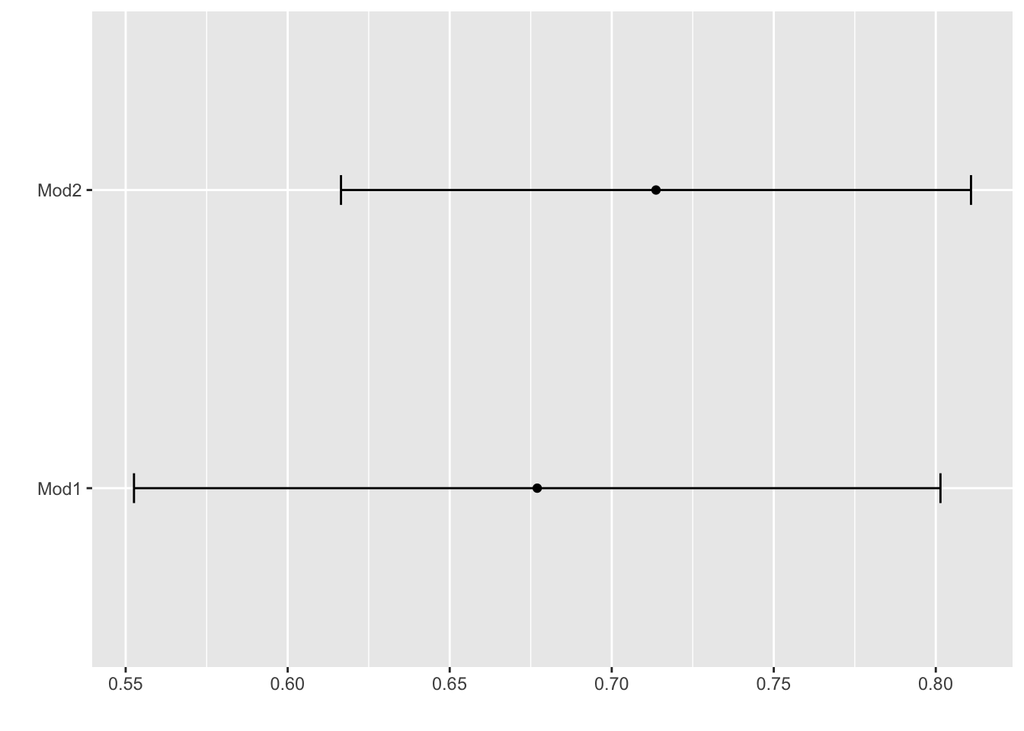

```r
ggplot(results, metric="RMSE")
```

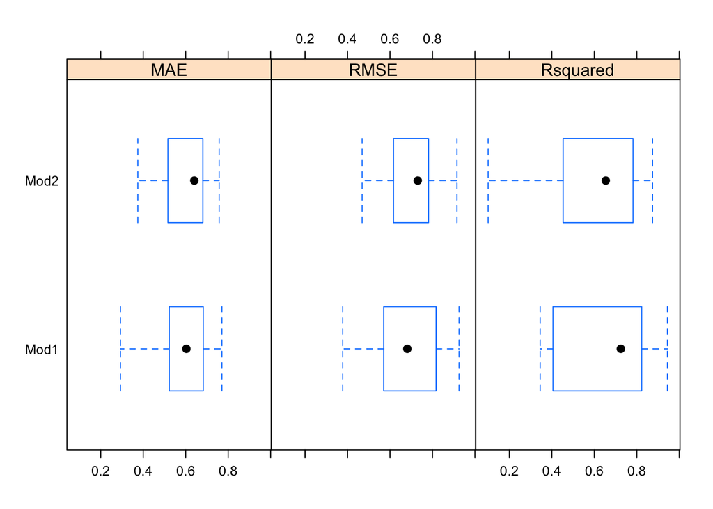

```r
bwplot(results)
```

This sort of result is fairly typical in statistical practice. Models that tend to *fit* the training data (i.e., that data used to build the model) well do **not** predict that well, whereas models that predict well do **not** always coincide with fitting the training data well.

**In general, simpler models tend to have smaller prediction errors.** (Our Model 1 only has two predictor variables whereas Model 2 has four predictor variables.)